# Model Seasonal ARIMA (SARIMA)

# Packages

```r
library(tidyverse)
library(forecast)
library(TSA)
library(aTSA)
library(lmtest)
library(car)
library(MASS)
```

# Pendahuluan

**Seasonal Autoregressive Integrated Moving Average (SARIMA)** merupakan pengembangan dari model Autoregressive Integrated Moving Average (ARIMA) pada data deret waktu yang memiliki pola musiman.

Model ARIMA musiman menggabungkan faktor-faktor non-musiman (regular) dan musiman dalam model multiplikasi, dengan notasi ARIMA(p,d,q)×(P,D,Q)s dengan:

- p = non-seasonal AR order,
- d = non-seasonal differencing,
- q = non-seasonal MA order,
- P = seasonal AR order,
- D = seasonal differencing,
- Q = seasonal MA order,
- s = time span of repeating seasonal pattern.

Tahapan identifikasi model SARIMA sama halnya seperti yang dilakukan pada model ARIMA regular atau model ARIMA non-seasonal, yaitu :

1. Plot time series
2. Identifikasi model
3. Pendugaan parameter model
4. Seleksi Model
5. Melakukan peramalan menggunakan model terbaik

# Impor Data

```r
data <- read.csv("D:\\IPB\\Statistika Sem 5\\MPDW (Deret Waktu)\\Data Jumlah Penumpang Transjakarta Harian Tahun 2023-2024.csv", sep =";")
data <- data[219:379,1:2]
data$periode_data <- as.Date(data$periode_data,format="%d/%m/%Y")
head(data)
```

```
##     periode_data jumlah_penumpang_transjakarta
## 219   2023-08-07                       1006666
## 220   2023-08-08                       1011406
## 221   2023-08-09                       1000208
## 222   2023-08-10                        991508
## 223   2023-08-11                        982905
## 224   2023-08-12                        676818
```

```r
class(data)
```

```
## [1] "data.frame"
```

```r
# ubah kelas data menjadi data frame
data.ts <- ts(data$jumlah_penumpang_transjakarta, frequency = 7)
data.ts
```

```
## Time Series:
## Start = c(1, 1)
## End = c(23, 7)
## Frequency = 7
##   [1] 1006666 1011406 1000208  991508  982905  676818  597413 1008471 1011261
##  [10]  989925  535537  941749  625534  498446  433517  418970  416837  409463
##  [19]  408345  282422  246739  420126  422024  430748  417971 1015361  695963
##  [28]  617558 1026591 1014345 1014851 1007231 1032009  700670  621726 1065550
##  [37] 1078830 1074826 1070391 1064895  711037  605562 1080611 1094329 1101370
##  [46] 1090495 1081846  742942  611442 1100966 1105993 1109120  615710 1043002
##  [55]  730363  650239 1083284 1105891 1100992 1102279 1087623  725319  630556
##  [64] 1100382 1109216 1107503 1103250 1093067  727497  635855 1107316 1128713
##  [73] 1121625 1110376 1097821  721052  629687 1104758 1120393 1107625 1111359
##  [82] 1097914  748153  633768 1109764 1121596 1117922 1121811 1101969  735079
##  [91]  642921 1121028 1130181 1128956 1124007 1101730  748574  653803 1135364
## [100] 1146542 1132691 1131441 1126115  744568  654569 1146384 1149804 1171288
## [109] 1145343 1118527  698469  642518 1147858 1153413 1158450 1140648 1127659
## [118]  769649  662120 1149169 1174098 1167902 1164122 1123681  781721  674405
## [127] 1151083 1156065 1151501 1143117 1131174  758456  680941 1083773 1081461
## [136] 1089583 1070707 1027720  749305  708769  609034  735852 1012112 1010097
## [145]  974703  748326  660343  632778 1045214 1041663 1097752 1105303  716205
## [154]  624900 1137742 1150147 1147436 1125270 1129099  758105  683688
```

```r
class(data.ts)
```

```
## [1] "ts"
```

# Eksplorasi Data

## Time Series Plot

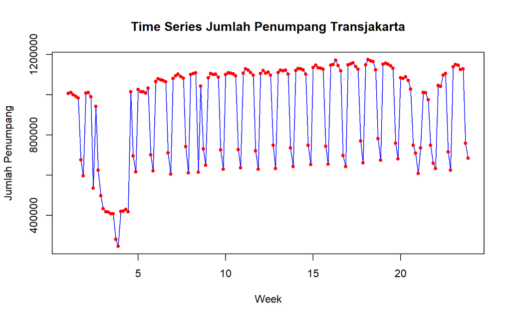

```r
ts.plot(data.ts, type="l", xlab = "Week", ylab="Jumlah Penumpang", col="blue")
title(main = "Time Series Jumlah Penumpang Transjakarta", cex.sub = 0.8)
points(data.ts, pch = 20, col = "red")
```

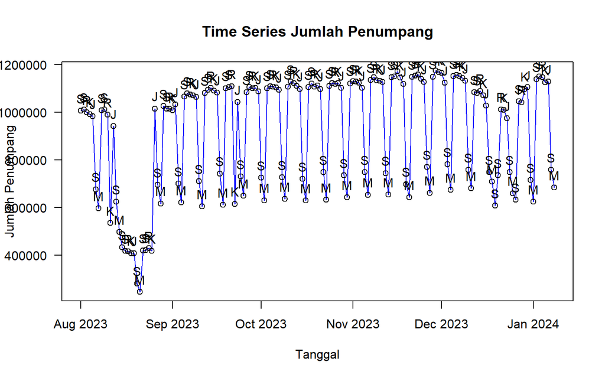

```r
# Menambahkan pola hari sesuai dengan urutan M, S, S, R, K, J, S
day_pattern <- c('S', 'S', 'R', 'K', 'J', 'S', 'M')
days <- rep(day_pattern, length.out = nrow(data))
data$day <- days

# Membuat plot time series
plot(data$periode_data, data$jumlah_penumpang_transjakarta, type = "n", xaxt = "n", xlab = "Tanggal", ylab = "Jumlah Penumpang", main = "Time Series Jumlah Penumpang", las=2)
lines(data$periode_data, data$jumlah_penumpang_transjakarta, col = "blue")

# Menambahkan label hari pada setiap titik
text(data$periode_data, data$jumlah_penumpang_transjakarta, labels = data$day, pos = 3, cex = 0.)

# Menambahkan titik untuk setiap data
points(data$periode_data, data$jumlah_penumpang_transjakarta, pch = 1)

axis.Date(1, at = seq(min(data$periode_data), max(data$periode_data), by = "month"), format = "%b %Y")
```

## Decompose Plot

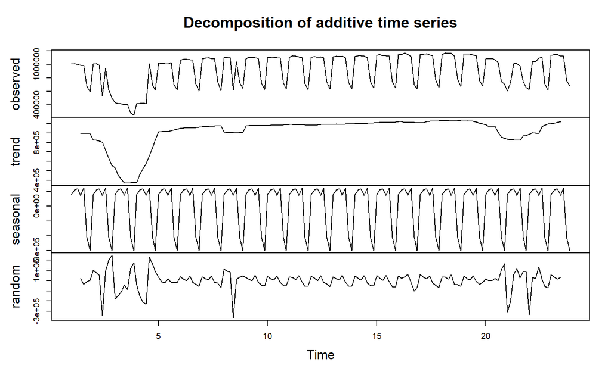

```r
decomposed.ts <- decompose(data.ts)
plot(decomposed.ts)
```

Secara eksploratif, terlihat bahwa adanya pola musiman dalam data tersebut. Pola musiman ini terlihat dapat terlihat jelas pada plot time series dan plot dekomposisi. Selain itu, data tersebut memiliki tren cenderung naik.

## Seasonal Plot

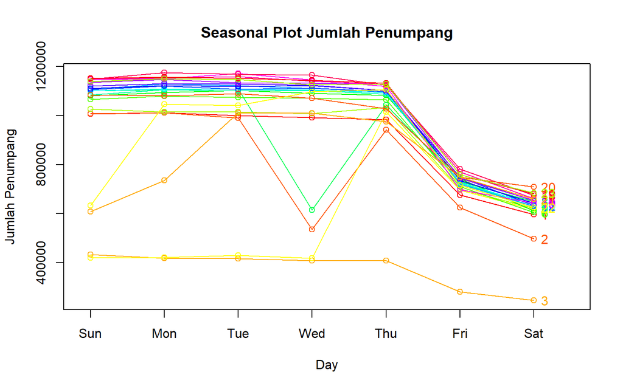

```r
seasonplot(data.ts,7,main="Seasonal Plot Jumlah Penumpang", ylab="Jumlah Penumpang",
           year.labels = TRUE, col=rainbow(18))
```

## Weeky Plot

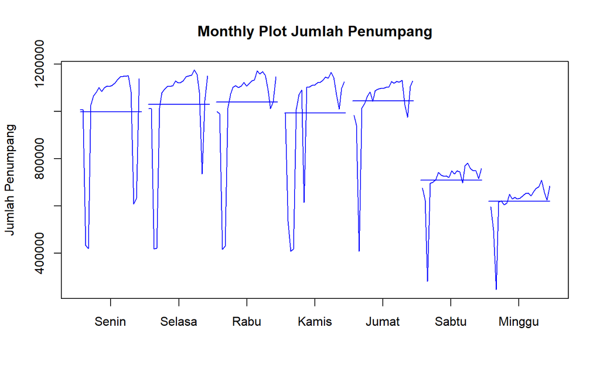

```r
monthplot(data.ts, main="Monthly Plot Jumlah Penumpang", ylab="Jumlah Penumpang", col= "blue", xaxt = "n")
axis(1, at=1:7, labels=c('Senin', 'Selasa', 'Rabu', 'Kamis', 'Jumat', 'Sabtu', 'Minggu'))
```

Gambar menunjukkan bahwa jumlah penumpang transjakarta tinggi pada weekdays, yaitu hari senin, selasa, rabu, kamis, dan puncaknya adalah jumat Kemudian, untuk yang rendah ada pada saat weekend, yaitu hari sabtu dan minggu. Perilaku tersebut terus berulang dari minggu ke minggu

## Boxplot

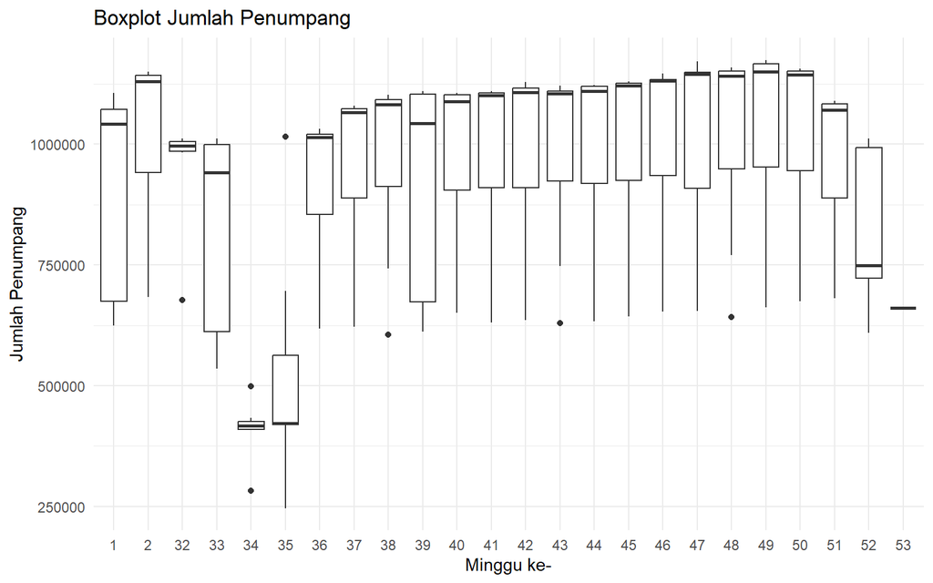

```r
data$minggu <- week(data$periode_data)

frame <- data.frame(values = data$jumlah_penumpang_transjakarta, date = factor(data$minggu))

# Membuat boxplot berdasarkan minggu dalam setahun
ggplot(frame, aes(x = date, y = values, group = date)) +
  geom_boxplot() +
  labs(x="Minggu ke-", y="Jumlah Penumpang", title="Boxplot Jumlah Penumpang") +
  theme_minimal()
```

# Uji Homogenitas

Uji asumsi formal terhadap kehomogenan ragam yang digunakan yaitu Fligner-Killen test, dimana:

*H0* : Ragam homogen

*H1* : Ragam tidak homogen

```r
fligner.test(values ~ date, data=frame)
```

```
##
##  Fligner-Killeen test of homogeneity of variances
##
## data:  values by date
## Fligner-Killeen:med chi-squared = 7.8768, df = 23, p-value = 0.9986
```

Berdasarkan hasil uji Fligner-Killeen dengan menggunakan taraf signifikansi α=5% didapatkan p-value sebesar 0.9986. **p−value=0.9986 > α=0.05** sehingga tak tolak H0 atau dengan kata lain **ragam data sudah stasioner**.

# Pembagian Data

Pembagian data dilakukan dengan mengambil sekitar 80% data awal (129 observasi) sebagai data latih dan 20% sisanya (32 observasi) sebagai data uji.

```r
train.ts <- subset(data.ts, start = 1, end = 129)
test.ts <- subset(data.ts, start = 130, end = 161)
```

## Plot Data Latih

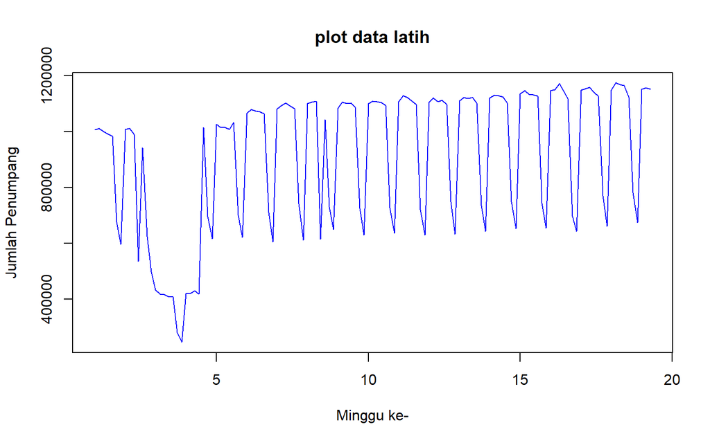

```r
ts.plot(train.ts, type="l", xlab = "Minggu ke-", ylab="Jumlah Penumpang", main = "plot data latih", col="blue")
```

## Plot Data Uji

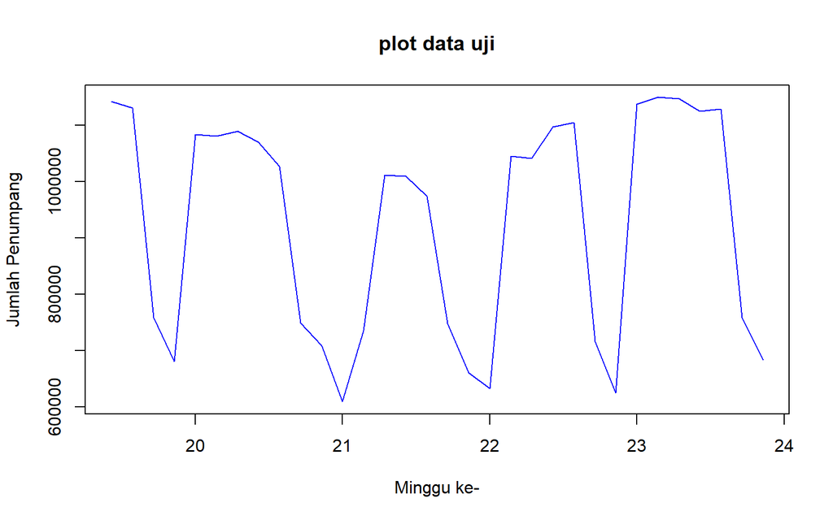

```r
ts.plot(test.ts, type="l", xlab = "Minggu ke-", ylab="Jumlah Penumpang", main = "plot data uji", col="blue")
```

# Cek Kestasioneran Data

## Kestasioneran dalam Rataan

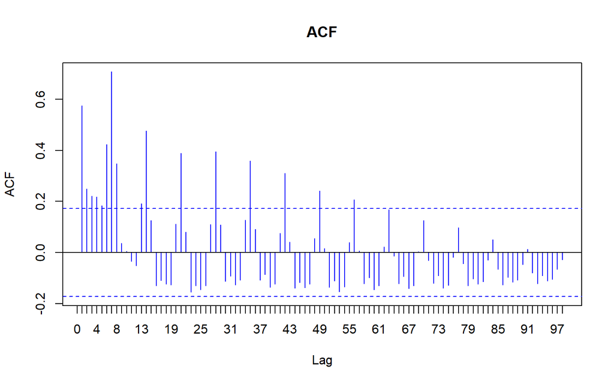

```r
#acf keseluruhan
acf0 <- acf(train.ts,main="ACF",lag.max=98,xaxt="n", col="blue")
axis(1, at=0:98/7, labels=0:98)
```

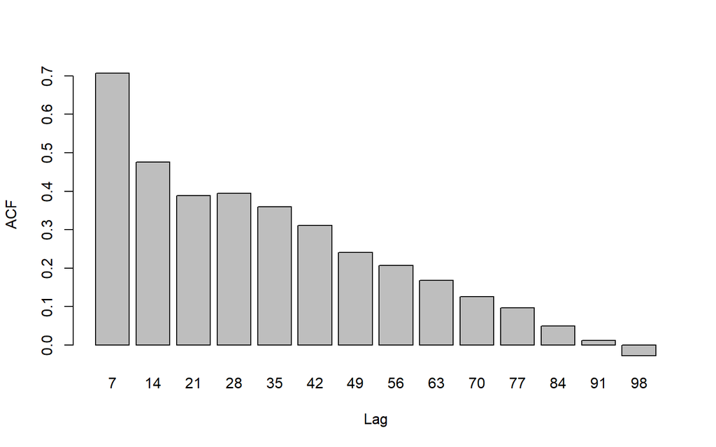

```r
#acf seasonal
acf0$lag <- acf0$lag * 7
acf0.1 <- as.data.frame(cbind(acf0$acf,acf0$lag))
acf0.2 <- acf0.1[which(acf0.1$V2%%7==0),]
barplot(height = acf0.2$V1,
names.arg=acf0.2$V2, ylab="ACF", xlab="Lag")
```

Dari kedua plot diatas, terlihat bahwa data tersebut memiliki periode musiman mingguan, sehingga s = 7. Plot ACF menyeluruh cenderung menunjukan pola **tails off slowly** yang menandakan bahwa data *tidak stasioner dalam rataan*. Hal ini juga ditunjukan oleh plot ACF seasonal dimana plot ACFnya cenderung **tails off slowly** , sehingga bisa dikatakan data *tidak stasioner dalam rataan*.

```r
tseries::adf.test(train.ts)
```

```
##
##  Augmented Dickey-Fuller Test
##
## data:  train.ts
## Dickey-Fuller = -2.721, Lag order = 5, p-value = 0.2768
## alternative hypothesis: stationary
```

*H0* : Data tidak stasioner dalam rataan

*H1* : Data stasioner dalam rataan

Berdasarkan uji ADF tersebut, didapat p-value sebesar 0.2768 yang lebih besar dari taraf nyata 5% sehingga tak tolak H0 dan menandakan bahwa data tidak stasioner dalam rataan. Hal ini sesuai dengan hasil eksplorasi menggunakan plot time series dan plot ACF. Oleh karena itu, ketidakstasioneran model kedepannya harus ditangani.

## Ketidakstasioneran dalam Ragam

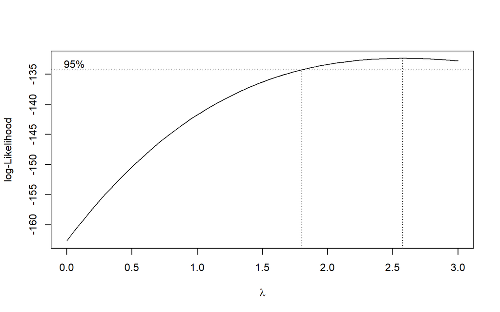

```r
index <- 1:length(train.ts)
bc1 <- boxcox(train.ts~index, lambda = seq(0,3,by=1))
```

```r
#Nilai Rounded Lambda
lambda <- bc1$x[which.max(bc1$y)]
lambda
```

```
## [1] 2.575758
```

```r
#SK
bc1$x[bc1$y > max(bc1$y) - 1/2 * qchisq(.95,1)]
```

```
##  [1] 1.818182 1.848485 1.878788 1.909091 1.939394 1.969697 2.000000 2.030303
##  [9] 2.060606 2.090909 2.121212 2.151515 2.181818 2.212121 2.242424 2.272727
## [17] 2.303030 2.333333 2.363636 2.393939 2.424242 2.454545 2.484848 2.515152
## [25] 2.545455 2.575758 2.606061 2.636364 2.666667 2.696970 2.727273 2.757576
## [33] 2.787879 2.818182 2.848485 2.878788 2.909091 2.939394 2.969697 3.000000
```

Berdasarkan hasil plot diatas, terlihat bahwa data tidak stasioner dalam ragam disebabkan nilai 1 tidak masuk dalam selang plot tersebut. Oleh karena itu, ketidakstasioneran model kedepannya harus ditangani.

# Penanganan Ketidakstasioneran

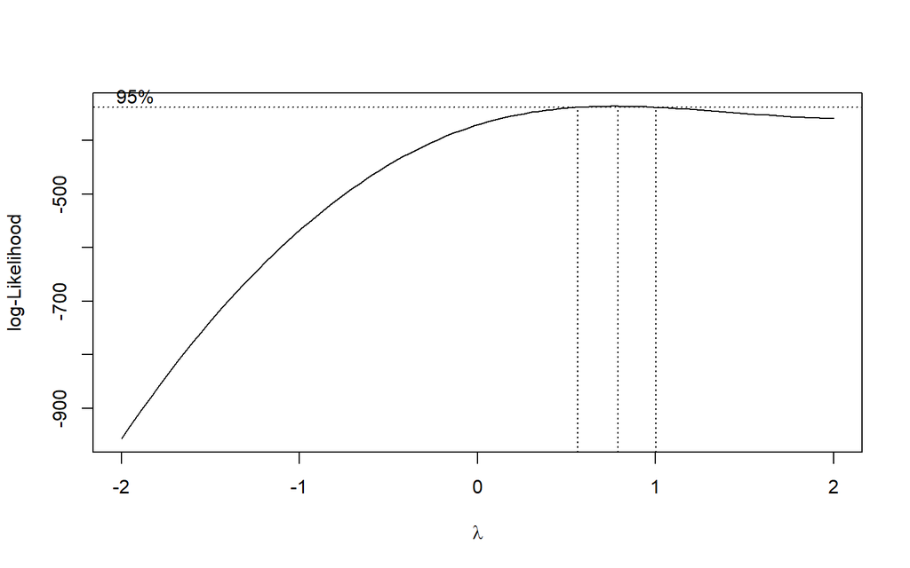

```r
# Transformasi Box-Cox
data.bc <- ((data.ts^lambda) - 1)/lambda

index <- 1:length(data.bc)
bc2 <- boxcox(data.bc~index, lambda = seq(-2,2,by=1))
```

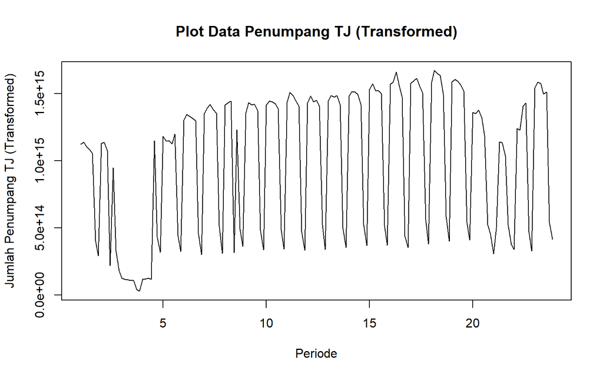

```r
# Plot data yang sudah ditransformasi
plot.ts(data.bc, lty=1, xlab="Periode", ylab="Jumlah Penumpang TJ (Transformed)", main="Plot Data Penumpang TJ (Transformed)")
```

```r
train.bc <- ts(data.bc[1:129], frequency = 7)
test.bc <- ts(data.bc[130:161], frequency = 7)
```

```r
tseries::adf.test(train.bc)
```

```
##
##  Augmented Dickey-Fuller Test
##
## data:  train.bc
## Dickey-Fuller = -3.1556, Lag order = 5, p-value = 0.09844
## alternative hypothesis: stationary
```

*H0* : Data tidak stasioner dalam rataan

*H1* : Data stasioner dalam rataan

# Non-Seasonal ARIMA

## Differencing (d1)

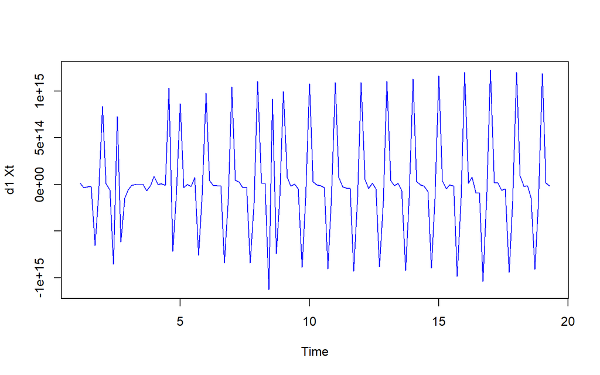

```r
#diff non-seasonal
d1 <- diff(train.bc)
ts.plot(d1, type="l", ylab="d1 Xt", col="blue")
```

*Differencing non-seasonal* **d = 1** jika dilihat berdasarkan plot di atas berhasil mengatasi ketidakstasioneran dalam rataan untuk komponen *non-seasonal*, tetapi masih terlihat pola musimannya.

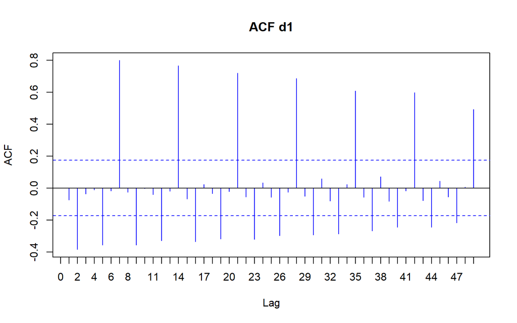

```r
#acf keseluruhan
acf1 <- acf(d1,lag.max=49,xaxt="n", main="ACF d1", col="blue")
axis(1, at=0:49/7, labels=0:49)
```

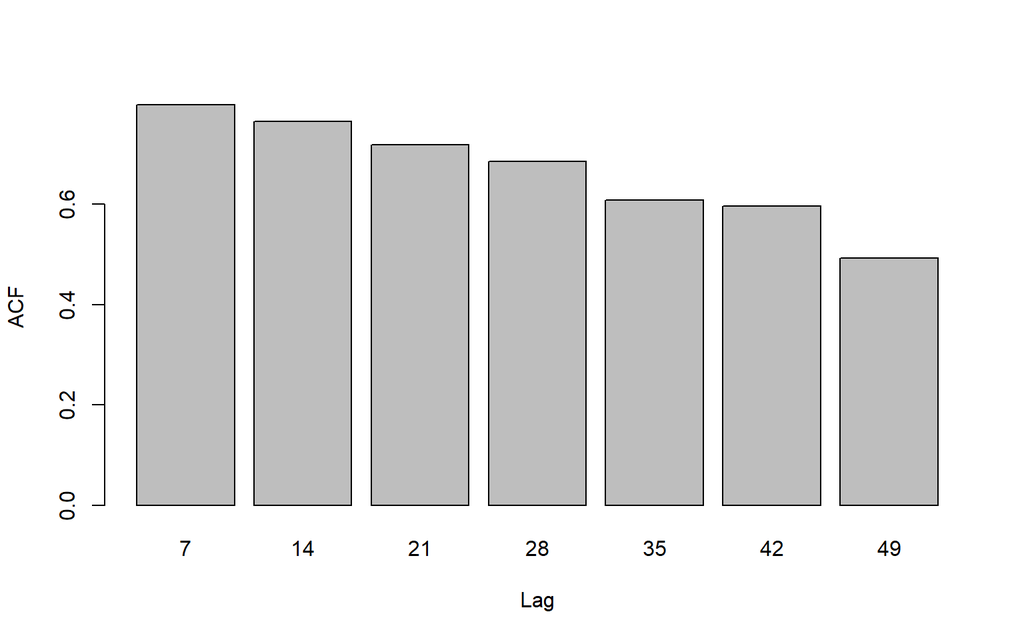

```r
#acf seasonalnya
acf2 <- acf1$lag <- acf1$lag * 7
acf1.1 <- as.data.frame(cbind(acf1$acf,acf1$lag))
acf1.2 <- acf1.1[which(acf1.1$V2%%7==0),]
barplot(height = acf1.2$V1, names.arg=acf1.2$V2, ylab="ACF", xlab="Lag")
```

Dari plot ACF data *non-seasonal differencing* **d = 1** terlihat bahwa data belum stasioner dalam rataan karena cenderung membentuk pola *tails off*. Hal ini juga terjadi untuk komponen seasonalnya yang terlihat cenderung membentuk pola *tails off*

# Seasonal ARIMA

## Differencing (D1)

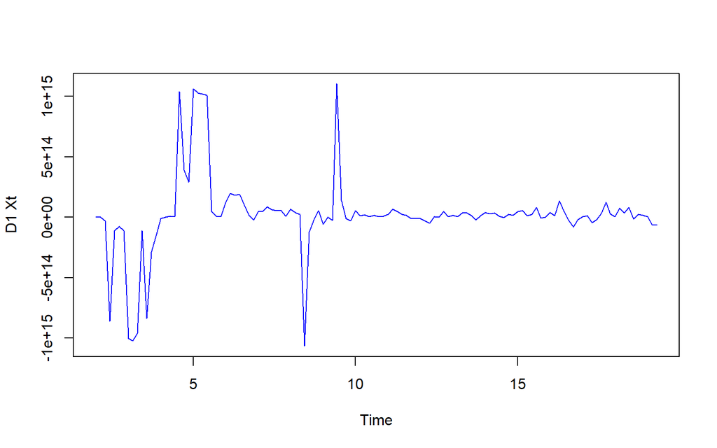

```r
#diff seasonal
D1 <- diff(train.bc, lag = 7)
ts.plot(D1, type="l", ylab="D1 Xt", col="blue")
```

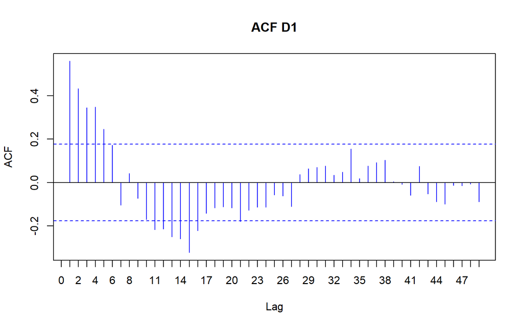

```r
acf2 <- acf(D1,lag.max=49,xaxt="n", main="ACF D1", col="blue")
axis(1, at=0:49/7, labels=0:49)
```

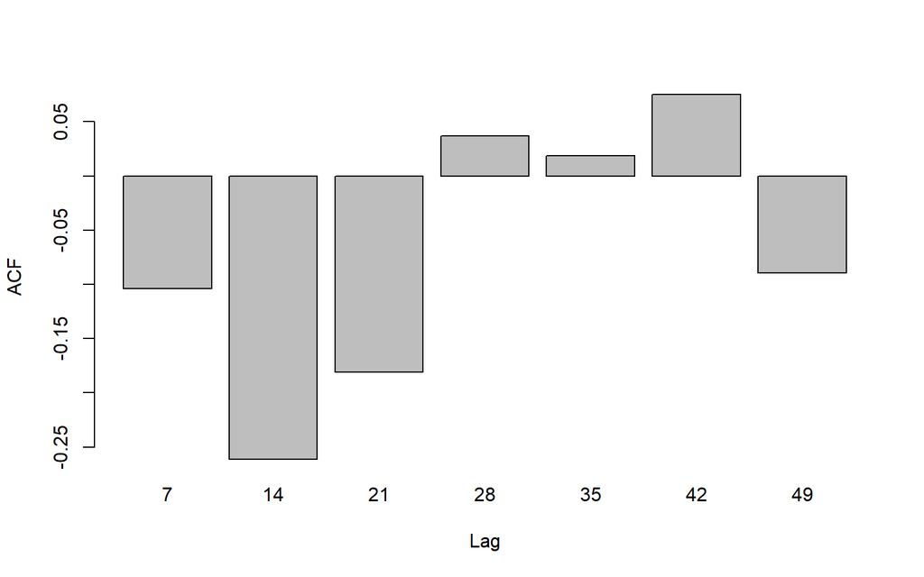

```r
acf2$lag <- acf2$lag * 7
acf2.1 <- as.data.frame(cbind(acf2$acf,acf2$lag))
acf2.2 <- acf2.1[which(acf2.1$V2%%7==0),]
barplot(height = acf2.2$V1, names.arg=acf2.2$V2, ylab="ACF", xlab="Lag")
```

Dari plot ACF data non-seasonal differencing **D = 1** berhasil menangani ketidakstasioneran dalam rataan untuk komponen non-seasonalnya maupun seasonalnya.

# Identifikasi Model

## Plot ACF

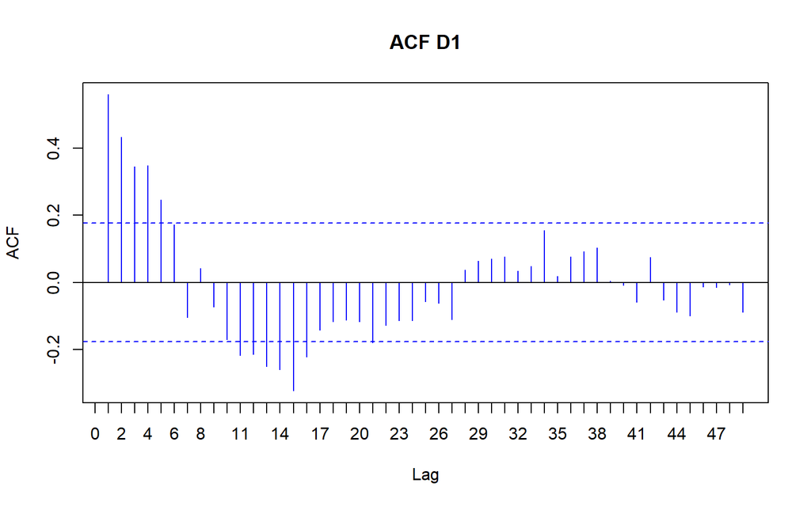

```r
acf3 <- acf(D1,lag.max=49,xaxt="n", main="ACF D1", col="blue")
axis(1, at=0:49/7, labels=0:49)
```

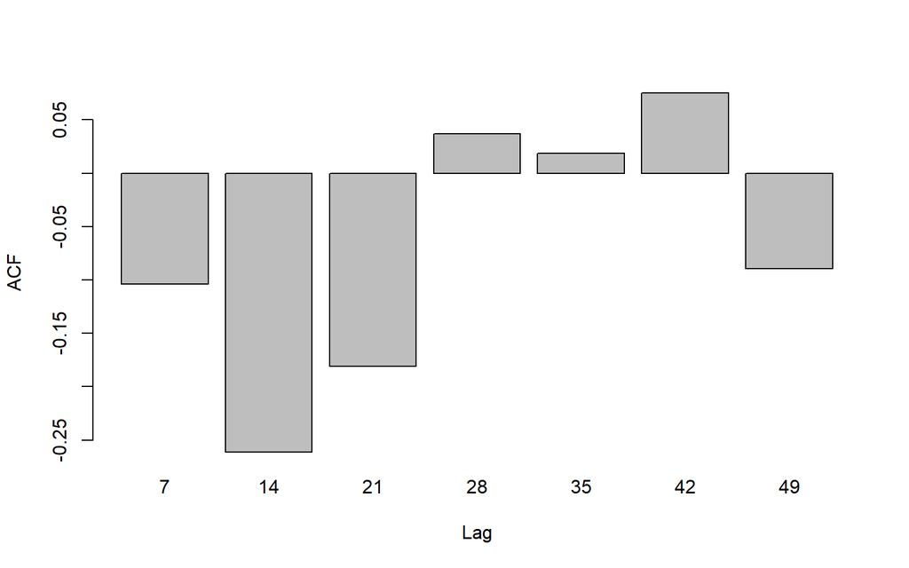

```r
acf3$lag <- acf3$lag * 7
acf3.1 <- as.data.frame(cbind(acf3$acf,acf3$lag))
acf3.2 <- acf3.1[which(acf3.1$V2%%7==0),]
barplot(height = acf3.2$V1, names.arg=acf3.2$V2, ylab="ACF",
xlab="Lag")
```

Plot ACF menunjukkan komponen non-seasonalnya membentuk *tails off* sehingga dipilih ordo p = 1 dan komponen seasonalnya cut off pada lag 3 sehingga dipilih ordo Q = 3.

Model tentatif : ARIMA (1,1,0) x (0,1,3)7

## Plot PACF

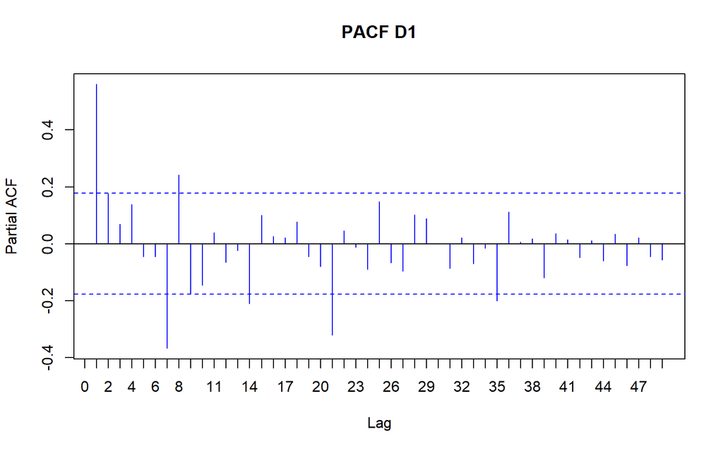

```r
pacf3 <- pacf(D1,lag.max=49,xaxt="n", main="PACF D1", col="blue")
axis(1, at=0:49/7, labels=0:49)
```

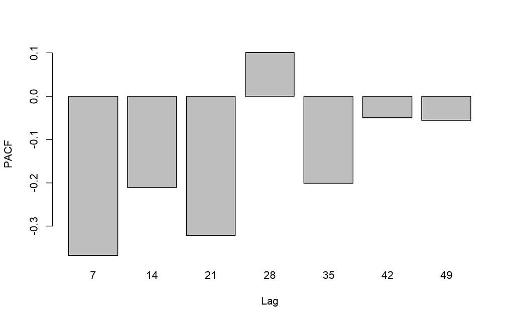

```r
pacf3$lag <- pacf3$lag * 7
pacf3.1 <- as.data.frame(cbind(pacf3$acf,pacf3$lag))
pacf3.2 <- pacf3.1[which(pacf3.1$V2%%7==0),]
barplot(height = pacf3.2$V1, names.arg=pacf3.2$V2, ylab="PACF", xlab="Lag")
```

Berdasarkan plot PACF, komponen non-seasonalnya *cut off* pada lag 1 sehingga dipilih ordo p = 1 dan komponen seasonalnya *cut off* pada lag 3 sehingga dipilih ordo P = 3. Kemudian, pada plot PACF non-seasonalnya ada kecenderungan *tails off* sehingga dipilih ordo q = 1.

Model tentatif : ARIMA (1,1,0) x (3,1,0)7 dan ARIMA (0,1,1) x (3,1,0)7

Model musiman yang dipilih untuk deret jumlah penumpang transjakarta berdasarkan plot ACF dan PACF adalah

**ARIMA(1,1,0) x (0,1,3)7, ARIMA(1,1,0) x (3,1,0)7, ARIMA(0,1,1) x (3,1,0)7**

## EACF

```r
TSA::eacf(D1)
```

```
## AR/MA
##   0 1 2 3 4 5 6 7 8 9 10 11 12 13
## 0 x x x x x o o o o o x  x  x  x
## 1 x o o o o o o o o o o  o  o  o
## 2 x o o o o o o o o o o  o  o  o
## 3 x x x o o o o o o o o  o  o  o
## 4 x x x o o o o o o o o  o  o  o
## 5 x o x o o o x x o o o  o  o  o
## 6 o o x o x x x x o o o  o  o  o
## 7 x o x x o o o o o o o  o  o  o
```

Berdasarkan hasil EACF, model yang dipilih adalah ARIMA(1,1,1), ARIMA(1,1,2), ARIMA((1,1,3), ARIMA(0,1,5).

# Model Tentatif

Dari hasil identifikasi model diatas, maka model tentatif yang akan digunakan adalah :

- ARIMA(1,1,0) x (0,1,3)7
- ARIMA(1,1,0) x (3,1,0)7
- ARIMA(0,1,1) x (3,1,0)7
- ARIMA(1,1,1) x (0,1,3)7
- ARIMA(1,1,1) x (3,1,0)7
- ARIMA(1,1,2) x (0,1,3)7
- ARIMA(1,1,2) x (3,1,0)7
- ARIMA(1,1,3) x (0,1,3)7
- ARIMA(1,1,3) x (3,1,0)7
- ARIMA(0,1,5) x (0,1,3)7
- ARIMA(0,1,5) x (3,1,0)7

# Pendugaan Parameter

## ARIMA(1,1,0) x (0,1,3)7

```r
tmodel1 <- Arima(train.bc, order = c(1,1,0), seasonal = list(order = c(0,1,3), period = 7))
summary(tmodel1)
```

```
## Series: train.bc
## ARIMA(1,1,0)(0,1,3)[7]
##
## Coefficients:
##           ar1     sma1    sma2    sma3
##       -0.2219  -0.7205  0.0118  0.0412
## s.e.   0.0929   0.1058  0.1058  0.1176
##
## sigma^2 = 5.586e+28:  log likelihood = -4176.66
## AIC=8363.31   AICc=8363.83   BIC=8377.29
##
## Training set error measures:
##                        ME         RMSE          MAE      MPE     MAPE      MASE
## Training set 4.745544e+12 2.250762e+14 1.334195e+14 3.831419 44.59456 0.9329648
##                     ACF1
## Training set -0.04146379
```

```r
lmtest::coeftest(tmodel1)
```

```
##
## z test of coefficients:
##
##       Estimate Std. Error z value  Pr(>|z|)
## ar1  -0.221898   0.092933 -2.3877   0.01695 *
## sma1 -0.720451   0.105794 -6.8099 9.766e-12 ***
## sma2  0.011801   0.105770  0.1116   0.91116
## sma3  0.041184   0.117631  0.3501   0.72625
## ---
## Signif. codes:  0 '***' 0.001 '**' 0.01 '*' 0.05 '.' 0.1 ' ' 1
```

## ARIMA(1,1,0) x (3,1,0)7

```r
tmodel2 <- Arima(train.bc, order = c(1,1,0), seasonal = list(order = c(3,1,0), period = 7))
summary(tmodel2)
```

```
## Series: train.bc
## ARIMA(1,1,0)(3,1,0)[7]
##
## Coefficients:
##           ar1     sar1     sar2     sar3
##       -0.2201  -0.6764  -0.4339  -0.3565
## s.e.   0.0930   0.0934   0.1036   0.0993
##
## sigma^2 = 5.453e+28:  log likelihood = -4175.62
## AIC=8361.24   AICc=8361.76   BIC=8375.22
##
## Training set error measures:
##                        ME         RMSE          MAE      MPE     MAPE      MASE
## Training set 3.598251e+12 2.223978e+14 1.253163e+14 4.131686 43.72736 0.8763015
##                     ACF1
## Training set -0.04142724
```

```r
lmtest::coeftest(tmodel2)
```

```
##
## z test of coefficients:
##
##       Estimate Std. Error z value  Pr(>|z|)
## ar1  -0.220118   0.093019 -2.3664 0.0179636 *
## sar1 -0.676368   0.093350 -7.2455 4.308e-13 ***
## sar2 -0.433906   0.103648 -4.1864 2.835e-05 ***
## sar3 -0.356464   0.099258 -3.5913 0.0003291 ***
## ---
## Signif. codes:  0 '***' 0.001 '**' 0.01 '*' 0.05 '.' 0.1 ' ' 1
```

## ARIMA(0,1,1) x (3,1,0)7

```r
tmodel3 <- Arima(train.bc, order = c(0,1,1), seasonal = list(order = c(3,1,0), period = 7))
summary(tmodel3)
```

```
## Series: train.bc
## ARIMA(0,1,1)(3,1,0)[7]
##
## Coefficients:
##           ma1     sar1     sar2     sar3
##       -0.4316  -0.6281  -0.4346  -0.3645
## s.e.   0.1163   0.0926   0.1021   0.1004
##
## sigma^2 = 5.238e+28:  log likelihood = -4173.17
## AIC=8356.35   AICc=8356.87   BIC=8370.33
##
## Training set error measures:
##                        ME         RMSE          MAE      MPE     MAPE      MASE
## Training set 5.070804e+12 2.179625e+14 1.236473e+14 4.797513 44.91625 0.8646306
##                    ACF1
## Training set 0.08789526
```

```r
lmtest::coeftest(tmodel3)
```

```
##
## z test of coefficients:
##
##       Estimate Std. Error z value  Pr(>|z|)
## ma1  -0.431627   0.116250 -3.7129 0.0002049 ***
## sar1 -0.628051   0.092609 -6.7818 1.187e-11 ***
## sar2 -0.434613   0.102068 -4.2581 2.062e-05 ***
## sar3 -0.364507   0.100422 -3.6298 0.0002837 ***
## ---
## Signif. codes:  0 '***' 0.001 '**' 0.01 '*' 0.05 '.' 0.1 ' ' 1
```

## ARIMA(1,1,1) x (0,1,3)7

```r
tmodel4 <- Arima(train.bc, order = c(1,1,1), seasonal = list(order = c(0,1,3), period = 7))
summary(tmodel4)
```

```
## Series: train.bc
## ARIMA(1,1,1)(0,1,3)[7]
##
## Coefficients:
##          ar1      ma1     sma1     sma2    sma3
##       0.3587  -0.7087  -0.7129  -0.0236  0.0478
## s.e.  0.1630   0.1194   0.1048   0.1053  0.1175
##
## sigma^2 = 5.196e+28:  log likelihood = -4172.04
## AIC=8356.09   AICc=8356.83   BIC=8372.86
##
## Training set error measures:
##                        ME         RMSE         MAE      MPE     MAPE      MASE
## Training set 1.038654e+13 2.161571e+14 1.30392e+14 4.759381 44.21258 0.9117943
##                    ACF1
## Training set 0.01858621
```

```r
lmtest::coeftest(tmodel4)
```

```
##
## z test of coefficients:
##
##       Estimate Std. Error z value  Pr(>|z|)
## ar1   0.358722   0.162975  2.2011   0.02773 *
## ma1  -0.708697   0.119411 -5.9349 2.940e-09 ***
## sma1 -0.712906   0.104790 -6.8032 1.023e-11 ***
## sma2 -0.023569   0.105258 -0.2239   0.82282
## sma3  0.047840   0.117500  0.4072   0.68390
## ---
## Signif. codes:  0 '***' 0.001 '**' 0.01 '*' 0.05 '.' 0.1 ' ' 1
```

## ARIMA(1,1,1) x (3,1,0)7

```r
tmodel5 <- Arima(train.bc, order = c(1,1,1), seasonal = list(order = c(3,1,0), period = 7))
summary(tmodel5)
```

```
## Series: train.bc
## ARIMA(1,1,1)(3,1,0)[7]
##
## Coefficients:
##          ar1      ma1     sar1     sar2     sar3
##       0.3583  -0.7104  -0.6642  -0.4584  -0.3839
## s.e.  0.1669   0.1233   0.0907   0.1034   0.1010
##
## sigma^2 = 5.06e+28:  log likelihood = -4170.93
## AIC=8353.85   AICc=8354.59   BIC=8370.63
##
## Training set error measures:
##                        ME         RMSE          MAE      MPE     MAPE      MASE
## Training set 7.947706e+12 2.133103e+14 1.194221e+14 4.877285 42.44672 0.8350849
##                    ACF1
## Training set 0.01660988
```

```r
lmtest::coeftest(tmodel5)
```

```
##
## z test of coefficients:
##
##      Estimate Std. Error z value  Pr(>|z|)
## ar1   0.35832    0.16687  2.1473 0.0317703 *
## ma1  -0.71039    0.12326 -5.7632 8.252e-09 ***
## sar1 -0.66415    0.09069 -7.3233 2.419e-13 ***
## sar2 -0.45845    0.10345 -4.4317 9.351e-06 ***
## sar3 -0.38391    0.10096 -3.8024 0.0001433 ***
## ---
## Signif. codes:  0 '***' 0.001 '**' 0.01 '*' 0.05 '.' 0.1 ' ' 1
```

## ARIMA(1,1,2) x (0,1,3)7

```r
tmodel6 <- Arima(train.bc, order = c(1,1,2), seasonal = list(order = c(0,1,3), period = 7))
summary(tmodel6)
```

```
## Series: train.bc
## ARIMA(1,1,2)(0,1,3)[7]
##
## Coefficients:
##          ar1      ma1      ma2     sma1     sma2    sma3
##       0.2073  -0.5408  -0.0942  -0.7235  -0.0168  0.0497
## s.e.  0.3049   0.2989   0.1489   0.1062   0.1064  0.1165
##
## sigma^2 = 5.223e+28:  log likelihood = -4171.87
## AIC=8357.74   AICc=8358.73   BIC=8377.31
##
## Training set error measures:
##                        ME         RMSE          MAE      MPE     MAPE      MASE
## Training set 1.040222e+13 2.157752e+14 1.309641e+14 4.794073 44.28474 0.9157948
##                     ACF1
## Training set 0.002199768
```

```r
lmtest::coeftest(tmodel6)
```

```
##
## z test of coefficients:
##
##       Estimate Std. Error z value Pr(>|z|)
## ar1   0.207276   0.304933  0.6797  0.49667
## ma1  -0.540752   0.298851 -1.8094  0.07038 .
## ma2  -0.094178   0.148884 -0.6326  0.52702
## sma1 -0.723455   0.106174 -6.8139  9.5e-12 ***
## sma2 -0.016847   0.106408 -0.1583  0.87420
## sma3  0.049733   0.116467  0.4270  0.66937
## ---
## Signif. codes:  0 '***' 0.001 '**' 0.01 '*' 0.05 '.' 0.1 ' ' 1
```

## ARIMA(1,1,2) x (3,1,0)7

```r
tmodel7 <- Arima(train.bc, order = c(1,1,2), seasonal = list(order = c(3,1,0), period = 7))
summary(tmodel7)
```

```
## Series: train.bc
## ARIMA(1,1,2)(3,1,0)[7]
##
## Coefficients:
##          ar1      ma1      ma2     sar1     sar2     sar3
##       0.2111  -0.5474  -0.0901  -0.6732  -0.4628  -0.3845
## s.e.  0.2990   0.2921   0.1426   0.0921   0.1039   0.1007
##
## sigma^2 = 5.088e+28:  log likelihood = -4170.75
## AIC=8355.51   AICc=8356.5   BIC=8375.08
##
## Training set error measures:
##                        ME         RMSE          MAE      MPE     MAPE      MASE
## Training set 7.922258e+12 2.129673e+14 1.197129e+14 4.939759 42.49949 0.8371185
##                      ACF1
## Training set 0.0004287172
```

```r
lmtest::coeftest(tmodel7)
```

```
##
## z test of coefficients:
##
##       Estimate Std. Error z value  Pr(>|z|)
## ar1   0.211093   0.298998  0.7060 0.4801886
## ma1  -0.547411   0.292057 -1.8743 0.0608849 .
## ma2  -0.090124   0.142635 -0.6319 0.5274839
## sar1 -0.673191   0.092079 -7.3110 2.651e-13 ***
## sar2 -0.462809   0.103946 -4.4524 8.491e-06 ***
## sar3 -0.384533   0.100705 -3.8184 0.0001343 ***
## ---
## Signif. codes:  0 '***' 0.001 '**' 0.01 '*' 0.05 '.' 0.1 ' ' 1
```

## ARIMA(1,1,3) x (0,1,3)7

```r
tmodel8 <- Arima(train.bc, order = c(1,1,3), seasonal = list(order = c(0,1,3), period = 7))
summary(tmodel8)
```

[output not shown]

```
##           ar1     ma1      ma2      ma3     sma1     sma2    sma3
##       -0.9578  0.6486  -0.4871  -0.2616  -0.6679  -0.0827  0.0687
## s.e.      NaN     NaN   0.0432   0.0525   0.1018   0.0919  0.0817
##
## sigma^2 = 5.056e+28:  log likelihood = -4169.52
## AIC=8355.05   AICc=8356.33   BIC=8377.41
##
## Training set error measures:
##                        ME         RMSE          MAE      MPE     MAPE      MASE
## Training set 1.011586e+13 2.113825e+14 1.313281e+14 5.944791 45.20627 0.9183398
##                      ACF1
## Training set -0.003309026
```

```r
lmtest::coeftest(tmodel8)
```

```
##
## z test of coefficients:
##
##       Estimate Std. Error  z value  Pr(>|z|)
## ar1  -0.957797        NaN      NaN       NaN
## ma1   0.648575        NaN      NaN       NaN
## ma2  -0.487082   0.043177 -11.2810 < 2.2e-16 ***
## ma3  -0.261586   0.052452  -4.9872 6.127e-07 ***
## sma1 -0.667943   0.101776  -6.5628 5.279e-11 ***
## sma2 -0.082700   0.091877  -0.9001    0.3681
## sma3  0.068710   0.081717   0.8408    0.4004
## ---
## Signif. codes:  0 '***' 0.001 '**' 0.01 '*' 0.05 '.' 0.1 ' ' 1
```

## ARIMA(1,1,3) x (3,1,0)7

```r
tmodel9 <- Arima(train.bc, order = c(1,1,3), seasonal = list(order = c(3,1,0), period = 7))
summary(tmodel9)
```

```
## Series: train.bc
## ARIMA(1,1,3)(3,1,0)[7]
##
## Coefficients:
##           ar1     ma1      ma2      ma3     sar1     sar2     sar3
##       -0.8431  0.5444  -0.4251  -0.2788  -0.6427  -0.4568  -0.3827
## s.e.   0.1344  0.1484   0.1043   0.0905   0.0959   0.1017   0.1018
##
## sigma^2 = 4.926e+28:  log likelihood = -4168.45
## AIC=8352.9   AICc=8354.19   BIC=8375.27
##
## Training set error measures:
##                        ME         RMSE         MAE      MPE     MAPE      MASE
## Training set 8.034242e+12 2.086409e+14 1.22823e+14 5.978928 42.87674 0.8588663
##                     ACF1
## Training set -0.01566308
```

```r
lmtest::coeftest(tmodel9)
```

```
##
## z test of coefficients:
##
##       Estimate Std. Error z value  Pr(>|z|)
## ar1  -0.843057   0.134393 -6.2730 3.540e-10 ***
## ma1   0.544395   0.148367  3.6692 0.0002433 ***
## ma2  -0.425107   0.104278 -4.0767 4.569e-05 ***
## ma3  -0.278849   0.090514 -3.0807 0.0020648 **
## sar1 -0.642708   0.095879 -6.7033 2.037e-11 ***
## sar2 -0.456792   0.101669 -4.4930 7.024e-06 ***
## sar3 -0.382702   0.101813 -3.7589 0.0001707 ***
## ---
## Signif. codes:  0 '***' 0.001 '**' 0.01 '*' 0.05 '.' 0.1 ' ' 1
```

## ARIMA(0,1,5) x (0,1,3)7

```r
tmodel10 <- Arima(train.bc, order = c(0,1,5), seasonal = list(order = c(0,1,3), period = 7))
summary(tmodel10)
```

```
## Series: train.bc
## ARIMA(0,1,5)(0,1,3)[7]
##
## Coefficients:
##           ma1      ma2      ma3     ma4     ma5     sma1    sma2    sma3
##       -0.3668  -0.2064  -0.1092  0.1594  0.1377  -0.8003  0.0259  0.1019
## s.e.   0.0958   0.1164   0.0834  0.1152  0.1138   0.1228  0.1135  0.1101
##
## sigma^2 = 5.145e+28:  log likelihood = -4170.05
## AIC=8358.11   AICc=8359.73   BIC=8383.27
##
## Training set error measures:
##                        ME         RMSE          MAE      MPE     MAPE      MASE
## Training set 7.136154e+12 2.122903e+14 1.305067e+14 8.537143 46.87571 0.9125966
##                    ACF1
## Training set 0.02986489
```

```r
lmtest::coeftest(tmodel10)
```

```
##
## z test of coefficients:
##
##       Estimate Std. Error z value  Pr(>|z|)
## ma1  -0.366848   0.095773 -3.8304 0.0001279 ***
## ma2  -0.206418   0.116401 -1.7733 0.0761726 .
## ma3  -0.109198   0.083436 -1.3088 0.1906112
## ma4   0.159438   0.115241  1.3835 0.1665075
## ma5   0.137720   0.113809  1.2101 0.2262407
## sma1 -0.800339   0.122828 -6.5160 7.223e-11 ***
## sma2  0.025883   0.113494  0.2281 0.8196051
## sma3  0.101910   0.110102  0.9256 0.3546563
## ---
## Signif. codes:  0 '***' 0.001 '**' 0.01 '*' 0.05 '.' 0.1 ' ' 1
```

## ARIMA(0,1,5) x (3,1,0)7

```r
tmodel11 <- Arima(train.bc, order = c(0,1,5), seasonal = list(order = c(3,1,0), period = 7))
summary(tmodel11)
```

```
## Series: train.bc
## ARIMA(0,1,5)(3,1,0)[7]
##
## Coefficients:
##           ma1      ma2      ma3     ma4     ma5     sar1     sar2     sar3
##       -0.3433  -0.1928  -0.1421  0.1909  0.1302  -0.7463  -0.5276  -0.4206
## s.e.   0.0939   0.1072   0.0874  0.1076  0.1118   0.1024   0.1100   0.0998
##
## sigma^2 = 4.924e+28:  log likelihood = -4168.09
## AIC=8354.17   AICc=8355.8   BIC=8379.34
##
## Training set error measures:
##                        ME         RMSE         MAE      MPE     MAPE      MASE
## Training set 5.508721e+12 2.076811e+14 1.22078e+14 8.681811 45.02274 0.8536569
##                    ACF1
## Training set 0.01791586
```

```r
lmtest::coeftest(tmodel11)
```

```
##
## z test of coefficients:
##
##       Estimate Std. Error z value  Pr(>|z|)
## ma1  -0.343252   0.093895 -3.6557 0.0002565 ***
## ma2  -0.192818   0.107161 -1.7993 0.0719652 .
## ma3  -0.142132   0.087448 -1.6253 0.1040898
## ma4   0.190866   0.107638  1.7732 0.0761927 .
## ma5   0.130163   0.111759  1.1647 0.2441530
## sar1 -0.746286   0.102373 -7.2899 3.102e-13 ***
## sar2 -0.527603   0.109995 -4.7966 1.614e-06 ***
## sar3 -0.420589   0.099782 -4.2151 2.497e-05 ***
## ---
## Signif. codes:  0 '***' 0.001 '**' 0.01 '*' 0.05 '.' 0.1 ' ' 1
```

## Ringkasan Hasil

```r
AICKandidatModel <- c(tmodel1$aic, tmodel2$aic, tmodel3$aic, tmodel4$aic, tmodel5$aic, tmodel6$aic, tmodel7$aic, tmodel8$aic, tmodel9$aic, tmodel10$aic, tmodel11$aic)

AICcKandidatModel <- c(tmodel1$aicc, tmodel2$aicc, tmodel3$aicc, tmodel4$aicc, tmodel5$aicc, tmodel6$aicc, tmodel7$aicc, tmodel8$aicc, tmodel9$aicc, tmodel10$aicc, tmodel11$aicc)

BICkandidatModel <- c(tmodel1$bic, tmodel2$bic, tmodel3$bic, tmodel4$bic, tmodel5$bic, tmodel6$bic, tmodel7$bic, tmodel8$bic, tmodel9$bic, tmodel10$bic, tmodel11$bic)

KandidatModelARIMA <- c("ARIMA(1,1,0) x (0,1,3)7 [tmodel1]", "ARIMA(1,1,0) x (3,1,0)7 [tmodel2]", "ARIMA(0,1,1) x (3,1,0)7 [tmodel3]", "ARIMA(1,1,1) x (0,1,3)7 [tmodel4]", "ARIMA(1,1,1) x (3,1,0)7 [tmodel5]", "ARIMA(1,1,2) x (0,1,3)7 [tmodel6]", "ARIMA(1,1,2) x (3,1,0)7 [tmodel7]", "ARIMA(1,1,3) x (0,1,3)7 [tmodel8]", "ARIMA(1,1,3) x (3,1,0)7 [tmodel9]", "ARIMA(0,1,5) x (0,1,3)7 [tmodel10]", "ARIMA(0,1,5) x (3,1,0)7 [tmodel11]")

compmodeARIMA <- data.frame(KandidatModelARIMA, AICKandidatModel, AICcKandidatModel, BICkandidatModel)

colnames(compmodeARIMA) <- c("Model", "AIC", "AICc", "BIC")
compmodeARIMA
```

```
##                                 Model      AIC     AICc      BIC
## 1   ARIMA(1,1,0) x (0,1,3)7 [tmodel1] 8363.313 8363.835 8377.292
## 2   ARIMA(1,1,0) x (3,1,0)7 [tmodel2] 8361.239 8361.761 8375.218
## 3   ARIMA(0,1,1) x (3,1,0)7 [tmodel3] 8356.346 8356.868 8370.325
## 4   ARIMA(1,1,1) x (0,1,3)7 [tmodel4] 8356.089 8356.826 8372.864
## 5   ARIMA(1,1,1) x (3,1,0)7 [tmodel5] 8353.850 8354.587 8370.625
## 6   ARIMA(1,1,2) x (0,1,3)7 [tmodel6] 8357.739 8358.730 8377.310
## 7   ARIMA(1,1,2) x (3,1,0)7 [tmodel7] 8355.506 8356.497 8375.076
## 8   ARIMA(1,1,3) x (0,1,3)7 [tmodel8] 8355.047 8356.333 8377.413
## 9   ARIMA(1,1,3) x (3,1,0)7 [tmodel9] 8352.900 8354.186 8375.266
## 10 ARIMA(0,1,5) x (0,1,3)7 [tmodel10] 8358.105 8359.727 8383.268
## 11 ARIMA(0,1,5) x (3,1,0)7 [tmodel11] 8354.174 8355.796 8379.337
```

```r
# Model dengan AIC dan AICc terkecil
compmodeARIMA %>% filter(AIC == min(AIC))
```

```
##                               Model    AIC     AICc      BIC
## 1 ARIMA(1,1,3) x (3,1,0)7 [tmodel9] 8352.9 8354.186 8375.266
```

```r
compmodeARIMA %>% filter(AICc == min(AICc))
```

```
##                               Model    AIC     AICc      BIC
## 1 ARIMA(1,1,3) x (3,1,0)7 [tmodel9] 8352.9 8354.186 8375.266
```

**Model terbaik** berdasarkan nilai AIC dan AICc terkecil serta semua parameternya signifikan adalah model 9, yaitu ARIMA(1,1,3) x (3,1,0)7

# Diagnostik Model

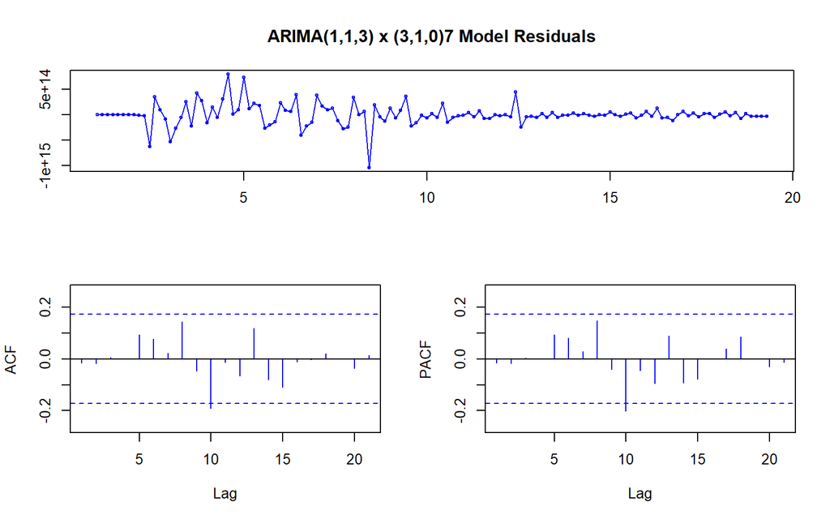

```r
tsdisplay(residuals(tmodel9), lag.max=21,
          main='ARIMA(1,1,3) x (3,1,0)7 Model Residuals', col="blue")
```

## Eksplorasi

```r
sisaan.model9 <- tmodel9$residuals
par(mfrow=c(2,2))
car::qqPlot(sisaan.model9, main="QQ Plot")
```

```
## [1] 53 26
```

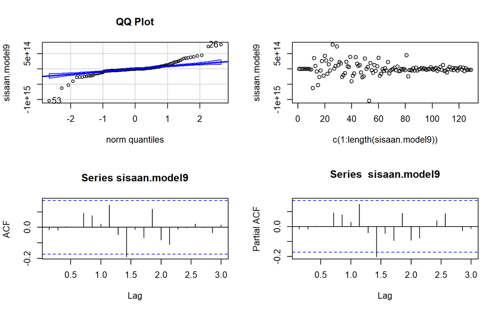

```r
plot(c(1:length(sisaan.model9)),sisaan.model9)
acf(sisaan.model9)
pacf(sisaan.model9)
```

```r
par(mfrow=c(1,1))
```

## Sisaan Menyebar Normal

```r
ks.test(sisaan.model9,"pnorm")
```

```
##
##  Asymptotic one-sample Kolmogorov-Smirnov test
##
## data:  sisaan.model9
## D = 0.52713, p-value < 2.2e-16
## alternative hypothesis: two-sided
```

```r
shapiro.test(sisaan.model9)
```

```
##
##  Shapiro-Wilk normality test
##
## data:  sisaan.model9
## W = 0.84644, p-value = 2.92e-10
```

```r
nortest::ad.test(sisaan.model9)
```

```
##
##  Anderson-Darling normality test
##
## data:  sisaan.model9
## A = 6.4834, p-value = 5.431e-16
```

Selain dengan eksplorasi, asumsi tersebut dapat diuji menggunakan uji formal. Pada tahapan ini uji formal yang digunakan untuk normalitas adalah uji Kolmogorov-Smirnov (KS), Shapiro-Wilk, dan Anderson-Darling. Hipotesis pada uji kenormalan adalah sebagai berikut.

H0 : Sisaan menyebar normal

H1 : Sisaan tidak menyebar normal

Berdasarkan semua uji tersebut, didapatkan p-value yang lebih kecil dari taraf nyata 5% sehingga tolak H0. Hal ini menunjukkan bahwa sisaan model tidak menyebar normal.

## Saling bebas/tidak ada autokorelasi

```r
Box.test(sisaan.model9, type = "Ljung-Box")
```

```
##
##  Box-Ljung test
##
## data:  sisaan.model9
## X-squared = 0.03239, df = 1, p-value = 0.8572
```

uji formal untuk kebebasan sisaan menggunakan uji Ljung-Box. Hipotesis yang digunakan adalah sebagai berikut.

H0 : Sisaan saling bebas

H1 : Sisaan tidak tidak saling bebas

Berdasarkan uji Ljung-Box tersebut, didapat p-value sebesar 0.8572 yang lebih besar dari taraf nyata 5% sehingga tak tolak H0 dan menandakan bahwa sisaan saling bebas. Hal ini berbeda dengan eksplorasi.

## Sisaan Homogen

```r
Box.test((sisaan.model9)^2, type = "Ljung-Box")
```

```
##
##  Box-Ljung test
##
## data:  (sisaan.model9)^2
## X-squared = 0.13967, df = 1, p-value = 0.7086
```

Hipotesis yang digunakan untuk uji kehomogenan ragam adalah sebagai berikut.

H0 : Ragam sisaan homogen

H1 : Ragam sisaan tidak homogen

Berdasarkan uji Ljung-Box terhadap sisaan kuadrat tersebut, didapat p-value sebesar 0.7086 yang lebih besar dari taraf nyata 5% sehingga tak tolak H0 dan menandakan bahwa ragam sisaan homogen.

## Nilai tengah sisaan sama dengan nol

```r
t.test(sisaan.model9, mu = 0, conf.level = 0.95)
```

```
##
##  One Sample t-test
##
## data:  sisaan.model9
## t = 0.43599, df = 128, p-value = 0.6636
## alternative hypothesis: true mean is not equal to 0
## 95 percent confidence interval:
##  -2.842820e+13  4.449669e+13
## sample estimates:
##    mean of x
## 8.034242e+12
```

Terakhir, dengan uji-t, akan dicek apakah nilai tengah sisaan sama dengan nol. Hipotesis yang diujikan sebagai berikut.

H0 : nilai tengah sisaan sama dengan 0

H1 : nilai tengah sisaan tidak sama dengan 0

Berdasarkan uji-ttersebut, didapat p-value sebesar 0.6636 yang lebih besar dari taraf nyata 5% sehingga tak tolak H0 dan menandakan bahwa nilai tengah sisaan sama dengan nol. Hal ini berbeda dengan eksplorasi.

# Overfitting

ARIMA(1,1,3) x (3,1,0)7 adalah model diagnostik awal

## Overfitting komponen non seasonal

```r
tmodel9.ofp <- Arima(train.bc, order=c(2,1,3),seasonal=c(3,1,0))
summary(tmodel9.ofp)
```

```
## Series: train.bc
## ARIMA(2,1,3)(3,1,0)[7]
##
## Coefficients:
##           ar1      ar2      ma1     ma2      ma3     sar1     sar2     sar3
##       -0.0627  -0.5657  -0.2748  0.4007  -0.3468  -0.6504  -0.4578  -0.4084
## s.e.   0.3136   0.3560   0.3172  0.4172   0.1633   0.1155   0.1135   0.1033
##
## sigma^2 = 5.014e+28:  log likelihood = -4169.15
## AIC=8356.29   AICc=8357.92   BIC=8381.46
##
## Training set error measures:
##                        ME         RMSE          MAE      MPE    MAPE      MASE
## Training set 7.501116e+12 2.095789e+14 1.207586e+14 6.068094 42.3648 0.8444305
##                     ACF1
## Training set -0.00372569
```

```r
lmtest::coeftest(tmodel9.ofp)
```

```
##
## z test of coefficients:
##
##       Estimate Std. Error z value  Pr(>|z|)
## ar1  -0.062746   0.313563 -0.2001   0.84140
## ar2  -0.565690   0.356023 -1.5889   0.11208
## ma1  -0.274835   0.317249 -0.8663   0.38632
## ma2   0.400700   0.417173  0.9605   0.33680
## ma3  -0.346783   0.163309 -2.1235   0.03371 *
## sar1 -0.650423   0.115502 -5.6313 1.789e-08 ***
## sar2 -0.457792   0.113488 -4.0338 5.487e-05 ***
## sar3 -0.408357   0.103298 -3.9532 7.711e-05 ***
## ---
## Signif. codes:  0 '***' 0.001 '**' 0.01 '*' 0.05 '.' 0.1 ' ' 1
```

```r
tmodel9.ofq <- Arima(train.bc, order=c(1,1,4),seasonal=c(3,1,0))
summary(tmodel9.ofq)
```

```
## Series: train.bc
## ARIMA(1,1,4)(3,1,0)[7]
##
## Coefficients:
##          ar1      ma1     ma2     ma3     ma4     sar1     sar2     sar3
##       0.9083  -1.2609  0.1512  0.0083  0.1014  -0.6660  -0.4608  -0.4025
## s.e.  0.0692   0.1191  0.1481  0.1394  0.0962   0.0945   0.1044   0.0996
##
## sigma^2 = 4.904e+28:  log likelihood = -4169.07
## AIC=8356.13   AICc=8357.75   BIC=8381.29
##
## Training set error measures:
##                        ME        RMSE          MAE      MPE     MAPE      MASE
## Training set 1.396577e+13 2.07254e+14 1.166475e+14 5.703661 40.01698 0.8156829
##                     ACF1
## Training set -0.02275946
```

```r
lmtest::coeftest(tmodel9.ofq)
```

```
##
## z test of coefficients:
##
##        Estimate Std. Error  z value  Pr(>|z|)
## ar1   0.9082844  0.0691565  13.1337 < 2.2e-16 ***
## ma1  -1.2608822  0.1190865 -10.5879 < 2.2e-16 ***
## ma2   0.1512357  0.1481025   1.0212    0.3072
## ma3   0.0082973  0.1393853   0.0595    0.9525
## ma4   0.1013788  0.0961729   1.0541    0.2918
## sar1 -0.6660173  0.0944771  -7.0495 1.796e-12 ***
## sar2 -0.4607918  0.1044020  -4.4136 1.017e-05 ***
## sar3 -0.4024940  0.0996087  -4.0408 5.328e-05 ***
## ---
## Signif. codes:  0 '***' 0.001 '**' 0.01 '*' 0.05 '.' 0.1 ' ' 1
```

## Overfitting komponen seasonal

```r
tmodel9.ofP <- Arima(train.bc, order=c(1,1,3),seasonal=c(4,1,0))
summary(tmodel9.ofP)
```

```
## Series: train.bc
## ARIMA(1,1,3)(4,1,0)[7]
##
## Coefficients:
##           ar1     ma1      ma2      ma3     sar1     sar2     sar3     sar4
##       -0.8545  0.5477  -0.4357  -0.2761  -0.6516  -0.4748  -0.4095  -0.0492
## s.e.   0.1313  0.1449   0.1067   0.0909   0.0983   0.1103   0.1199   0.1140
##
## sigma^2 = 4.964e+28:  log likelihood = -4168.36
## AIC=8354.71   AICc=8356.34   BIC=8379.88
##
## Training set error measures:
##                        ME         RMSE          MAE      MPE     MAPE      MASE
## Training set 8.264455e+12 2.085163e+14 1.243817e+14 5.927212 43.17449 0.8697657
##                     ACF1
## Training set -0.01456896
```

```r
lmtest::coeftest(tmodel9.ofP)
```

```
##
## z test of coefficients:
##
##       Estimate Std. Error z value  Pr(>|z|)
## ar1  -0.854536   0.131314 -6.5076 7.637e-11 ***
## ma1   0.547673   0.144937  3.7787 0.0001577 ***
## ma2  -0.435713   0.106690 -4.0839 4.428e-05 ***
## ma3  -0.276122   0.090897 -3.0377 0.0023837 **
## sar1 -0.651570   0.098333 -6.6261 3.446e-11 ***
## sar2 -0.474797   0.110301 -4.3045 1.673e-05 ***
## sar3 -0.409498   0.119920 -3.4148 0.0006384 ***
## sar4 -0.049221   0.114032 -0.4316 0.6659987
## ---
## Signif. codes:  0 '***' 0.001 '**' 0.01 '*' 0.05 '.' 0.1 ' ' 1
```

```r
tmodel9.ofQ <- Arima(train.bc, order=c(1,1,3),seasonal=c(3,1,1))
summary(tmodel9.ofQ)
```

```
## Series: train.bc
## ARIMA(1,1,3)(3,1,1)[7]
##
## Coefficients:
##           ar1     ma1      ma2      ma3     sar1     sar2     sar3    sma1
##       -0.8338  0.5701  -0.3999  -0.2872  -1.0923  -0.6916  -0.4533  0.5145
## s.e.   0.1339  0.1465   0.1024   0.0928   0.2091   0.1494   0.0924  0.2301
##
## sigma^2 = 4.937e+28:  log likelihood = -4168.39
## AIC=8354.78   AICc=8356.4   BIC=8379.94
##
## Training set error measures:
##                        ME         RMSE          MAE      MPE     MAPE      MASE
## Training set 6.862614e+12 2.079479e+14 1.238352e+14 6.169969 42.41022 0.8659441
##                     ACF1
## Training set -0.01796503
```

```r
lmtest::coeftest(tmodel9.ofQ)
```

```
##
## z test of coefficients:
##
##       Estimate Std. Error z value  Pr(>|z|)
## ar1  -0.833798   0.133887 -6.2276 4.735e-10 ***
## ma1   0.570116   0.146485  3.8920 9.943e-05 ***
## ma2  -0.399923   0.102396 -3.9057 9.397e-05 ***
## ma3  -0.287181   0.092807 -3.0944  0.001972 **
## sar1 -1.092322   0.209139 -5.2229 1.761e-07 ***
## sar2 -0.691564   0.149361 -4.6302 3.654e-06 ***
## sar3 -0.453265   0.092428 -4.9040 9.391e-07 ***
## sma1  0.514519   0.230135  2.2357  0.025370 *
## ---
## Signif. codes:  0 '***' 0.001 '**' 0.01 '*' 0.05 '.' 0.1 ' ' 1
```

## Ringkasan Hasil Overfitting

```r
AICKandidatModelOF <- c(tmodel9$aic, tmodel9.ofp$aic, tmodel9.ofq$aic, tmodel9.ofP$aic, tmodel9.ofQ$aic)

AICcKandidatModelOF <- c(tmodel9$aicc, tmodel9.ofp$aicc, tmodel9.ofq$aicc, tmodel9.ofP$aicc, tmodel9.ofQ$aicc)

BICkandidatModelOF <- c(tmodel9$bic, tmodel9.ofp$bic, tmodel9.ofq$bic, tmodel9.ofP$bic, tmodel9.ofQ$bic)

KandidatModelARIMAOF <- c("ARIMA(1,1,3) x (3,1,0)7 [tmodel9]", "ARIMA(2,1,3) x (3,1,0)7 [tmodel9.ofp]", "ARIMA(1,1,4) x (3,1,0)7 [tmodel9.ofq]", "ARIMA(1,1,3) x (4,1,0)7 [tmodel9.ofP]", "ARIMA(1,1,3) x (3,1,1)7 [tmodel9.ofQ]")

compmodeARIMAOF <- data.frame(KandidatModelARIMAOF, AICKandidatModelOF, AICcKandidatModelOF, BICkandidatModelOF)

colnames(compmodeARIMAOF) <- c("Model", "AIC", "AICc", "BIC")

compmodeARIMAOF
```

```
##                                   Model      AIC     AICc      BIC
## 1     ARIMA(1,1,3) x (3,1,0)7 [tmodel9] 8352.900 8354.186 8375.266
## 2 ARIMA(2,1,3) x (3,1,0)7 [tmodel9.ofp] 8356.295 8357.916 8381.457
## 3 ARIMA(1,1,4) x (3,1,0)7 [tmodel9.ofq] 8356.133 8357.754 8381.295
## 4 ARIMA(1,1,3) x (4,1,0)7 [tmodel9.ofP] 8354.714 8356.336 8379.877
## 5 ARIMA(1,1,3) x (3,1,1)7 [tmodel9.ofQ] 8354.776 8356.398 8379.938
```

```r
# Model dengan AIC dan AICc terkecil
compmodeARIMAOF %>% filter(AIC == min(AIC))
```

```
##                               Model    AIC     AICc      BIC
## 1 ARIMA(1,1,3) x (3,1,0)7 [tmodel9] 8352.9 8354.186 8375.266
```

```r
compmodeARIMAOF %>% filter(AICc == min(AICc))
```

```
##                               Model    AIC     AICc      BIC
## 1 ARIMA(1,1,3) x (3,1,0)7 [tmodel9] 8352.9 8354.186 8375.266
```

Model overfitting yang dicobakan menghasilkan nilai AIC dan signifikansi parameter yang tidak lebih baik dari model awal, yaitu model 9. Oleh karena itu, model yang digunakan tetap model 9.